# Lab2

Daniel Yowell

2023-09-01

# Task 1

Get the working directory

```r
getwd()
```

```
## [1] "C:/Users/dyowe/Documents/RPackages/FALL224753yowe0004/Labs/Lab2"
```

# Task 2

Read EPAGAS into data frame

```r
data <- read.csv("EPAGAS.csv")
head(data)
```

```
##    MPG
## 1 36.3
## 2 41.0
## 3 36.9
## 4 37.1
## 5 44.9
## 6 36.8
```

# Task 3

Make the object mpg, the number of miles per gallon vector.

```r
mpg <- data$MPG
```

If $z_i=\frac{(x_i-\bar{x})}{s_x}$, then $\bar{z} = 0$ and $s_z^2 = 1$. Transform the mpg variable to z and verify these results.

```r
# Subtract mean from mpg, then divide by standard deviation
z=(mpg-mean(mpg))/sd(mpg)
print(z)
```

```
##   [1] -0.287026279  1.656811633 -0.038876758  0.043839749  3.269783517
##   [6] -0.080235012 -2.892596246  0.085198002  2.111752421 -0.121593265
##  [11] -1.775923403  0.126556256  1.739528140 -0.162951519 -1.693206896
##  [16] -0.204309772 -1.569132136  0.167914509  0.209272762 -1.403699122
##  [21]  1.450020366 -0.204309772  0.250631016 -1.279624361  1.325945605
##  [26] -0.245668025  0.291989269  0.291989269  1.243229098 -1.155549601
##  [31] -0.328384532  0.374705776 -0.411101039  0.374705776 -0.452459293
##  [36]  0.498780537  0.540138790 -0.535175800 -0.576534053 -0.783325320
##  [41]  0.622855297  0.829646564 -0.617892306 -0.907400081  0.664213550
##  [46]  0.995079578 -0.700608813 -1.072833094  0.746930057  1.119154338
##  [51] -0.287026279 -0.080235012 -1.858639910 -0.245668025  1.450020366
##  [56] -0.162951519 -0.369742786  0.498780537  0.581497043  0.953721324
##  [61]  1.656811633 -2.148147684  0.126556256 -1.610490389  0.002481495
##  [66]  0.250631016  0.002481495  0.705571804  0.829646564 -0.493817546
##  [71]  0.002481495  0.085198002  1.532736873  0.167914509  0.043839749
##  [76]  0.333347523 -0.452459293 -0.576534053 -0.121593265 -1.031474841
##  [81]  0.043839749  1.367303859 -0.121593265  0.002481495 -1.279624361
##  [86]  1.284587352  0.416064030 -0.741967067 -0.907400081  1.036437831
##  [91]  1.201870845 -0.038876758 -1.693206896 -1.320982615  1.160512592
##  [96] -1.238266108 -0.080235012 -0.824683574  0.457422283 -0.038876758
```

```r
# The mean of z is extremely close to zero
print(mean(z))
```

```
## [1] 1.058709e-16
```

```r
# The square of the standard deviation of z is 1
print(sd(z)^2)
```

```
## [1] 1
```

Using z, find the values of mpg that are possible outliers.

```r
z[abs(z)>=2 & abs(z)<=3]
```

```
## [1] -2.892596  2.111752 -2.148148
```

Using z, find the values of mpg that are defined as outliers.

```r
z[abs(z)>3]
```

```
## [1] 3.269784
```

Using the lattice package, construct a dotplot. (red = outlier, blue = possible outlier)

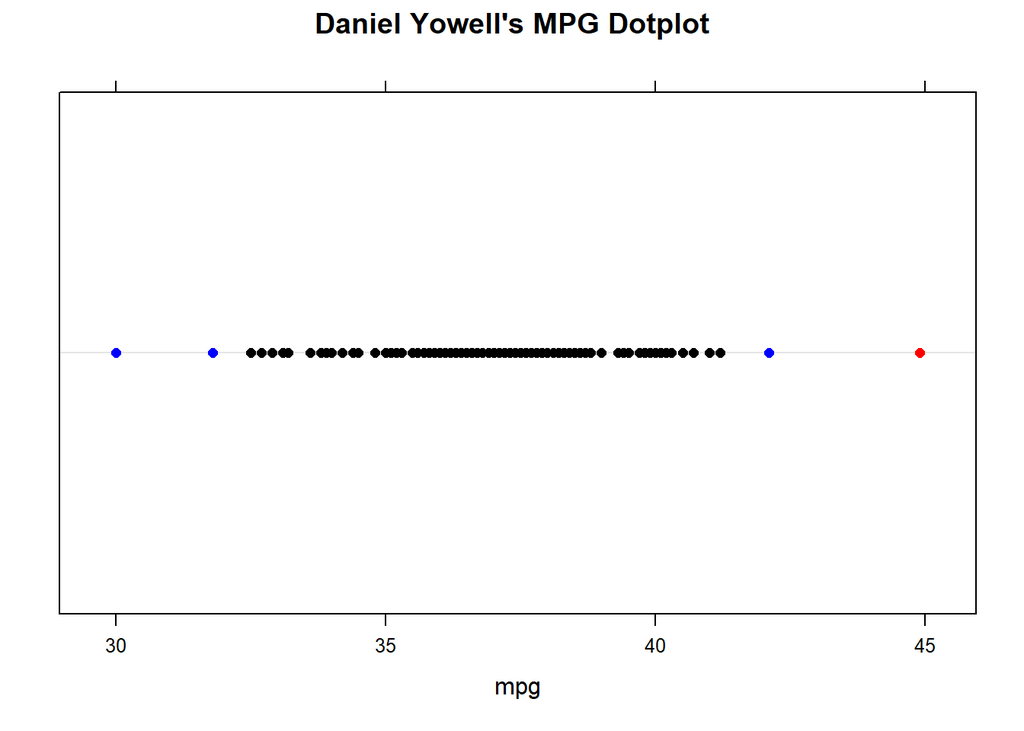

```r
# outliers = red, possible outliers = blue, rest = black
mycol = ifelse(abs(z)>3, "Red",
        ifelse(abs(z)>=2 &abs(z)<=3,"Blue", "Black"))

library(lattice)
dp <- dotplot(mpg,col=mycol, main="Daniel Yowell's MPG Dotplot")
print(dp)
```

# Task 4

Make a boxplot of the mpg variable.

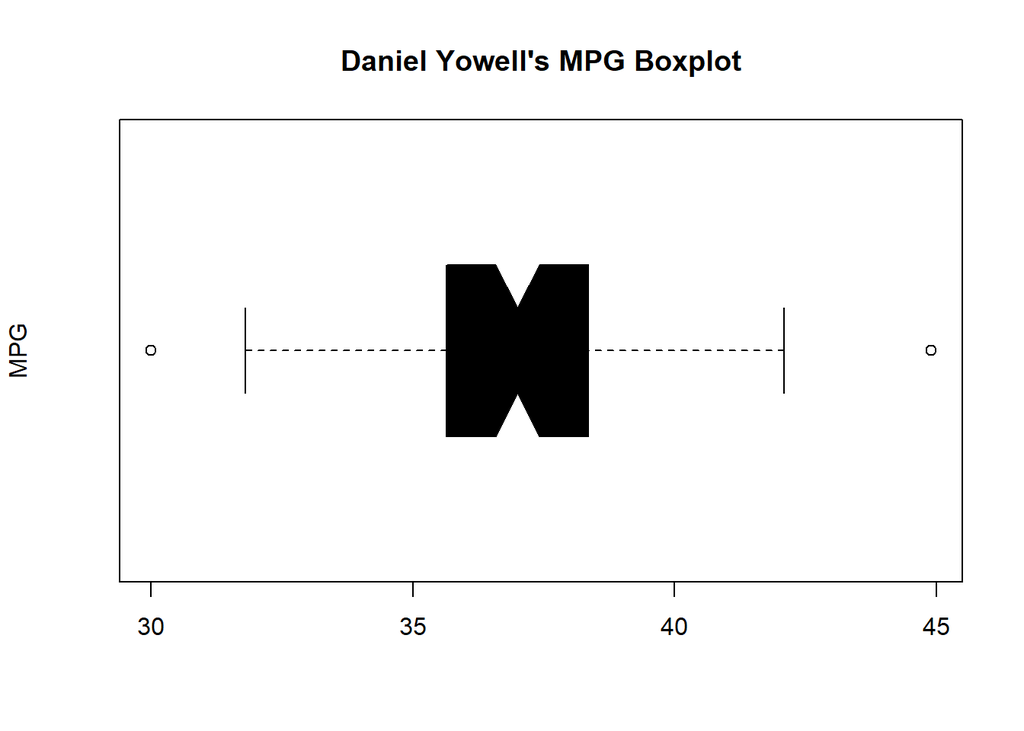

```r
boxplot(data$MPG, main="Daniel Yowell's MPG Boxplot", ylab="MPG", horizontal=TRUE, col="black", notch = TRUE)

# Median value
median_val <- median(data$MPG)

# Add the median line
abline(h = median_val)
```

Q: Using Chebyshev’s theorem predict the proportion of data within 2 standard deviations of the mean of the mpg data.

A: Chebyshev’s theorem says that at least 75% of the data lies within 2 standard deviations of the mean.

Use R to calculate the exact proportion within 2 standard deviation of the mean.

```r
mean_mpg <- mean(mpg)
print(mean_mpg)
```

```
## [1] 36.994
```

```r
sd2 <- sd(mpg) * 2
print(sd2)
```

```
## [1] 4.835794
```

```r
upperbound <- mean_mpg + sd2
lowerbound <- mean_mpg - sd2

subset <- mpg[mpg > lowerbound  & mpg < upperbound]
print(length(subset) / length(mpg))
```

```
## [1] 0.96
```

Q: Does Chebyshev agree with the data?

A: We have shown that 96% of the data lies within 2 standard deviations of the mean. Thus, Chebyshev agrees with the data.

Q: Now use the Empirical rule. What proportion (according to the rule) of the data should be within 2 standard deviations of the mean?

A: The Empirical rule says that 95% of the data should be within 2 standard deviations of the mean.

Q: How well does it correspond?

A: It’s a close call, but the 96% we found earlier is indeed greater than 95%. Thus, the Empirical rule holds up.

Q: Is the Empirical rule valid in this case? Why?

A: It is acceptable to use the Empirical rule here, since our data forms the shape of a single mound (as shown in the histogram below).

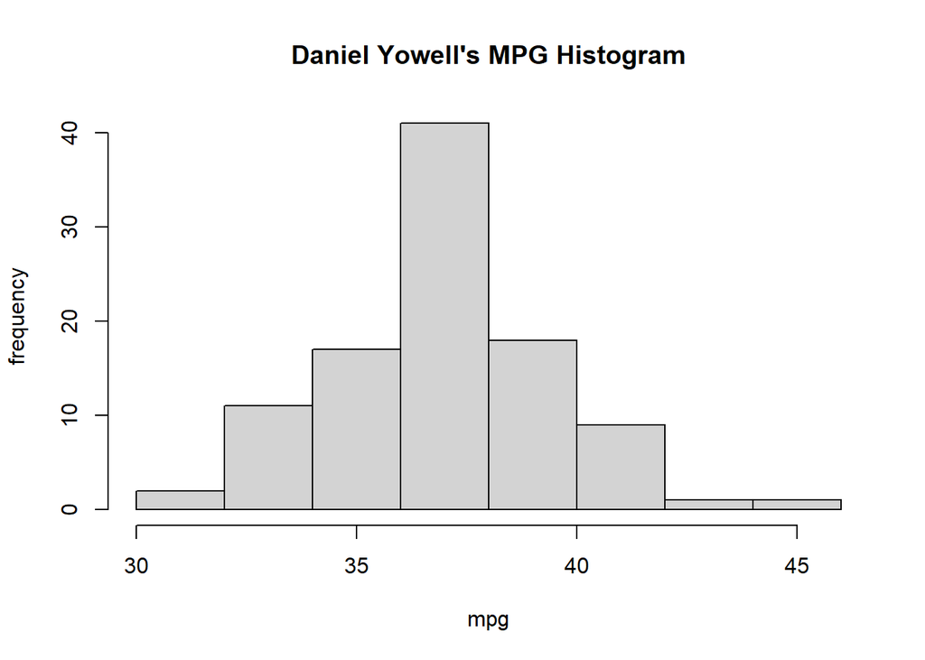

```r
hist(mpg,
     main = "Daniel Yowell's MPG Histogram",
     xlab = "mpg",
     ylab = "frequency")
```